# iMKT Pipeline

One of the most striking evidence of the power of natural selection is the characteristic footprints that it leaves on the patterns of genetic variation. A growing number of statistical methods to analyze genomic data allows us to detect and quantify adaptation and other selection regimes in the genome at different temporal scales (reviewed in Casillas and Barbadilla (2017)).

The McDonald and Kreitman test (MKT, McDonald and Kreitman (1991)) is one of the most powerful and robust methods we have to detect the action of natural selection at the DNA level.

The main drawback of MKT is that it assumes strict neutrality of segregating sites. Because weak negative selection abounds in the genomes (Casillas and Barbadilla 2017), $\alpha$ estimates are biased downward. Several MKT methodological extensions try to correct the bias. This package implements four such approaches, together with the standard MKT test (McDonald and Kreitman 1991): (i) the Fay, Wyckoff and Wu correction (FWW) (Fay et al. 2001); (ii) the extended MKT (eMKT) (Mackay et al. 2012); (iii) the asymptotic MKT (aMKT) (Messer and Petrov 2013) and (iv) the imputed MKT (impMKT) (Murga-Moreno et al. 2022). The Integrative McDonald and Kreitman Test (iMKT) package allows computing the McDonald and Kreitman test on polymorphism and divergence genomic data provided by the user or automatically downloaded from PopFly (Hervas et al. 2017) or PopHuman (Casillas et al. 2018).

In this document, we show how to install the package and how to analyze the sample data using different MKT-derived methods. Finally, we briefly discuss the results obtained with each of the available tests. This vignette contains three different sections:

- Loading the package and checking test data
- Performing MKT analyses
- Conclusion: comparison of the different MKT estimates

## Loading the package and checking test data

First of all, install (if this is not done yet) and load the `iMKT` package. Notice that iMKT package includes two sample data frames named `myDafData` and `myDivergenceData` which are the ones used in this tutorial and correspond to the polymorphism and divergence of genes from chromosome arm 2R of the North American Raleigh population (RAL, North Carolina, $n=205$), using *D. simulans* as outgroup species to estimate divergence metrics. Therefore, it is possible to replicate the vignettes in order to better understand all the package functionalities.

```r
## Install devtools if needed
# install.packages("devtools")
# devtools::install_github("BGD-UAB/iMKT")
library(iMKT)

## Sample daf data
head(myDafData)
```

```
#>     daf    Pi    P0
#> 1 0.025 22490 17189
#> 2 0.075  3217  4780
#> 3 0.125  1616  2874
#> 4 0.175   999  2088
#> 5 0.225   754  1685
#> 6 0.275   679  1443
```

```r
## Sample divergence data
myDivergenceData
```

```
#>        mi    Di     m0    D0
#> 1 2598805 54641 620019 52537
```

The iMKT package includes several functions, classified as follows:

**Calculation of MKT-derived methods**

- `standardMKT()`: Standard MKT
- `FWW()`: FWW correction
- `imputedMKT()`: imputed MKT correction
- `eMKT()`: extended MKT correction
- `asymptoticMKT()`: Asymptotic MKT and `aMKT()`: Asymptotic MKT with negative selection fractions
- `completimputedMKT()`: perform all previous tests

**iMKT using PopFly and PopHuman data**

- `loadPopFly()`: load PopFlyData
- `loadPopHuman()`: load PopHumanData
- `PopFlyAnalysis()`: perform any test using PopFlyData
- `PopHumanAnalysis()`: perform any test using PopHumanData

**Miscellaneous**

- `checkInput()`: check data before performing analyses
- `themePublication()`: output plots and tables styling

Each function has an associated help page with its description, details about its parameters, usage, examples and so on. Remember you can access it writing `?` and the function name (or `?library::function`) in your console (*example*: `?iMKT::standardMKT`).

This vignette focuses on the first category of functions: “Calculation of MKT-derived methods”. Specifically, it contains examples of each function using the sample data described above. For details about functions from “iMKT using PopFly and PopHuman data” category check the corresponding vignette (PopDataPipeline). The functions from the third category are used within other functions and do not produce analyses output.

## Performing MKT analyses

The functions from this category share two common input parameters, required to perform the corresponding test:

- `daf`: data frame containing DAF, $P_i$ and $P_0$ values (`myDafData`)
- `divergence`: data frame containing divergent and analyzed sites for selected (i) and neutral (0) classes (`myDivergenceData`)

The output of each function always contains the corresponding $\alpha$ estimate, together with specific values and details of the selected methodology.

### Standard MKT

The standard MKT (McDonald and Kreitman 1991) compares the ratio of non-synonymous to synonymous polymorphism ($P_i$/$P_0$) with the ratio of non-synonymous to synonymous divergence ($D_i$/$D_0$) in a 2×2 contingency table. Under strict neutrality, both ratios are expected to be equal; a significant excess of non-synonymous divergence relative to polymorphism ($\alpha > 0$) is interpreted as evidence of positive selection.

- **$\alpha$**: estimate of the proportion of adaptive substitutions using the standard MKT
- **Fisher exact test P-value**: p-value obtained using the Fisher exact test on a 2×2 contingency table (MKT table)
- **MKT table**: table containing the number of polymorphic and divergent sites for neutral and selected classes
- **Divergence metrics**: table containing estimates of $K_a$, $K_s$, $\omega$, $\omega_A$, $\omega_D$

```r
standardMKT(daf = myDafData, divergence = myDivergenceData)
```

```
#> $alpha
#>       alpha   Fisher.Test
#> 1 0.2364499 1.480943e-183
#>
#> $mktTable
#>                Polymorphism Divergence
#> Neutral class         45101      52537
#> Selected class        35816      54641
#>
#> $divMetrics
#>           Ka        Ks     omega     omegaA   omegaD
#> 1 0.02102543 0.0847345 0.2481331 0.05867104 0.189462
```

### FWW correction

$\alpha$ estimates can be biased by the segregation of slightly deleterious substitutions. One method to partially control this effect is to remove low frequency polymorphisms from the analysis, as proposed by Fay et al. (2001). Using this correction, all polymorphic sites from both neutral and selected classes which have a derived allele frequency lower than the pre-defined cutoff are removed for the calculation of alpha.

The **FWW()** function uses the `daf` and `divergence` input parameters, along with a required `listCutoffs` argument (e.g. `c(0, 0.05, 0.1)`) and returns as output a list containing:

- **Results**: $\alpha$ estimates (and their associated Fisher exact test P-value) for each cutoff
- **Divergence metrics**: global metrics ($K_a$, $K_s$, $\omega$) and estimates by cutoff ($\omega_A$, $\omega_D$)
- **MKT tables**: tables containing the number of polymorphic and divergent sites for neutral and selected classes for each cutoff

```r
FWW(daf = myDafData, divergence = myDivergenceData, listCutoffs = c(0, 0.05, 0.1))
```

```
#> $mktTable
#>                Polymorphism Divergence
#> Neutral class         45101      52537
#> Selected class        35816      54641
#>
#> $alphaCorrected
#>             cutoff alphaCorrected        pvalue
#> cutoff=0      0.00      0.2364499 1.480943e-183
#> cutoff=0.05   0.05      0.5409548  0.000000e+00
#> cutoff=0.1    0.10      0.5798139  0.000000e+00
#>
#> $divMetrics
#> $divMetrics$metricsByCutoff
#>             cutoff         Ka        Ks     omegaA    omegaD
#> cutoff=0      0.00 0.02102543 0.0847345 0.05867104 0.1894620
#> cutoff=0.05   0.05 0.02102543 0.0847345 0.13422877 0.1139043
#> cutoff=0.1    0.10 0.02102543 0.0847345 0.14387102 0.1042621
```

The argument **listCutoffs** takes a list of cutoffs. Moreover, the function has an optional argument, **plot**, which is set to **FALSE** by default. These parameters can be customized, like in the following example, where we use a list of 4 cutoffs (0.05, 0.15, 0.25, 0.35) and set the plot argument to **TRUE**.

The output in this case contains a **Graph** which shows the adaptation value (alpha) obtained using each cutoff.

```
#> $mktTable
#>                Polymorphism Divergence
#> Neutral class         45101      52537
#> Selected class        35816      54641
#>
#> $alphaCorrected
#>             cutoff alphaCorrected pvalue
#> cutoff=0.05   0.05      0.5409548      0
#> cutoff=0.15   0.15      0.5969015      0
#> cutoff=0.25   0.25      0.6068868      0
#> cutoff=0.35   0.35      0.6171609      0
#>
#> $divMetrics
#> $divMetrics$metricsByCutoff
#>             cutoff         Ka        Ks    omegaA     omegaD
#> cutoff=0.05   0.05 0.02102543 0.0847345 0.1342288 0.11390431
#> cutoff=0.15   0.15 0.02102543 0.0847345 0.1481110 0.10002208
#> cutoff=0.25   0.25 0.02102543 0.0847345 0.1505887 0.09754438
#> cutoff=0.35   0.35 0.02102543 0.0847345 0.1531380 0.09499504
#>
#>
#> $graph
```

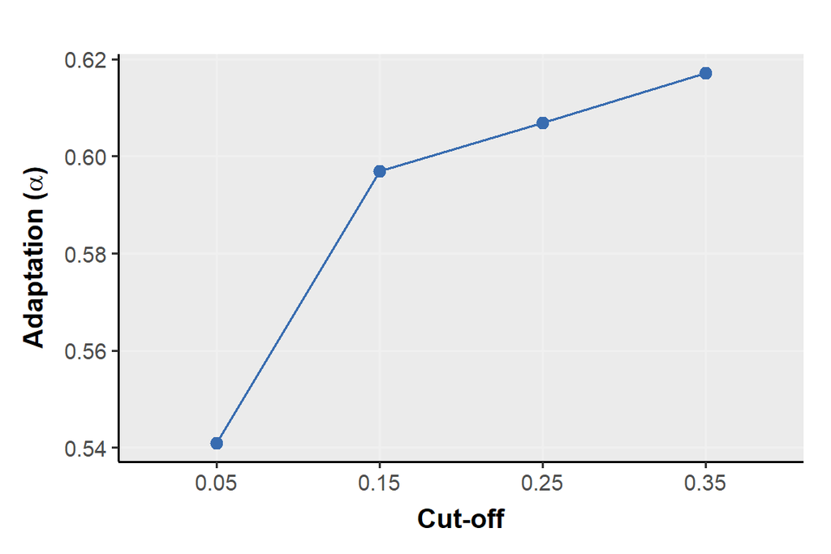

```r
FWW(daf = myDafData, divergence = myDivergenceData, listCutoffs=c(0.05, 0.15, 0.25, 0.35), plot = TRUE)
```

### imputedMKT correction

The imputed MKT is described in Murga-Moreno et al. (2022). Consider a pair of 2×2 contingency tables: the first one corresponds to the standard MKT table, with the observed counts of segregating and divergent sites for each cell; the second one contains the counts of $P_n$ and $P_s$ for two frequency categories, below and above a derived allele frequency (DAF) cutoff.

The imputed test corrects for weakly deleterious mutations by estimating their contribution from the ratio of low- to high-frequency synonymous polymorphisms. The expected number of weakly deleterious nonsynonymous polymorphisms below the cutoff is imputed as $P_{wd} = P_{n,low} - P_{n,high} \times \frac{P_{s,low}}{P_{s,high}}$. The corrected count $P_n^* = P_n - P_{wd}$ is then used in the standard 2×2 test to obtain a bias-corrected $\alpha = 1 - \frac{D_0 \cdot P_n^*}{D_n \cdot P_s}$. This approach retains more data than simple frequency filtering while still removing the downward bias from slightly deleterious variants.

The **imputedMKT()** function behaves similar to the **FWW()** function. It takes the same input arguments and returns the same output, but also containing estimates on the **fractions of negative selection** (d: strongly deleterious, f: neutral and b: weakly deleterious).

```r
imputedMKT(daf = myDafData, divergence = myDivergenceData, listCutoffs = c(0.05))
```

```
#> $mktTable
#>                Polymorphism Divergence
#> Neutral class         45101      52537
#> Selected class        35816      54641
#>
#> $alphaCorrected
#>             cutoff alphaCorrected pvalue
#> cutoff=0.05   0.05      0.5409548      0
#>
#> $divMetrics
#> $divMetrics$metricsByCutoff
#>             cutoff         Ka        Ks    omegaA    omegaD
#> cutoff=0.05   0.05 0.02102543 0.0847345 0.1342288 0.1139043
#>
#>
#> $fractions
#>             cutoff        d         f          b
#> cutoff=0.05   0.05 0.810538 0.1139043 0.07555773
```

Again, it also takes the argument **listCutoffs**. The argument **plot** is set to **FALSE** by default. These parameters can be customized, like in the previous example, where we use a list of 4 cutoffs (0.05, 0.15, 0.25, 0.35) and set the plot argument to **TRUE**.

The output in this case contains two **Graphs** which show the adaptation value ($\alpha$) and the negative selection fractions obtained using each cutoff.

```
#> $mktTable
#>                Polymorphism Divergence
#> Neutral class         45101      52537
#> Selected class        35816      54641
#>
#> $alphaCorrected
#>             cutoff alphaCorrected pvalue
#> cutoff=0.05   0.05      0.5409548      0
#> cutoff=0.15   0.15      0.5969015      0
#> cutoff=0.25   0.25      0.6068868      0
#> cutoff=0.35   0.35      0.6171609      0
#>
#> $divMetrics
#> $divMetrics$metricsByCutoff
#>             cutoff         Ka        Ks    omegaA     omegaD
#> cutoff=0.05   0.05 0.02102543 0.0847345 0.1342288 0.11390431
#> cutoff=0.15   0.15 0.02102543 0.0847345 0.1481110 0.10002208
#> cutoff=0.25   0.25 0.02102543 0.0847345 0.1505887 0.09754438
#> cutoff=0.35   0.35 0.02102543 0.0847345 0.1531380 0.09499504
#>
#>
#> $fractions
#>             cutoff        d          f          b
#> cutoff=0.05   0.05 0.810538 0.11390431 0.07555773
#> cutoff=0.15   0.15 0.810538 0.10002208 0.08943997
#> cutoff=0.25   0.25 0.810538 0.09754438 0.09191766
#> cutoff=0.35   0.35 0.810538 0.09499504 0.09446700
#>
#> $graph
```

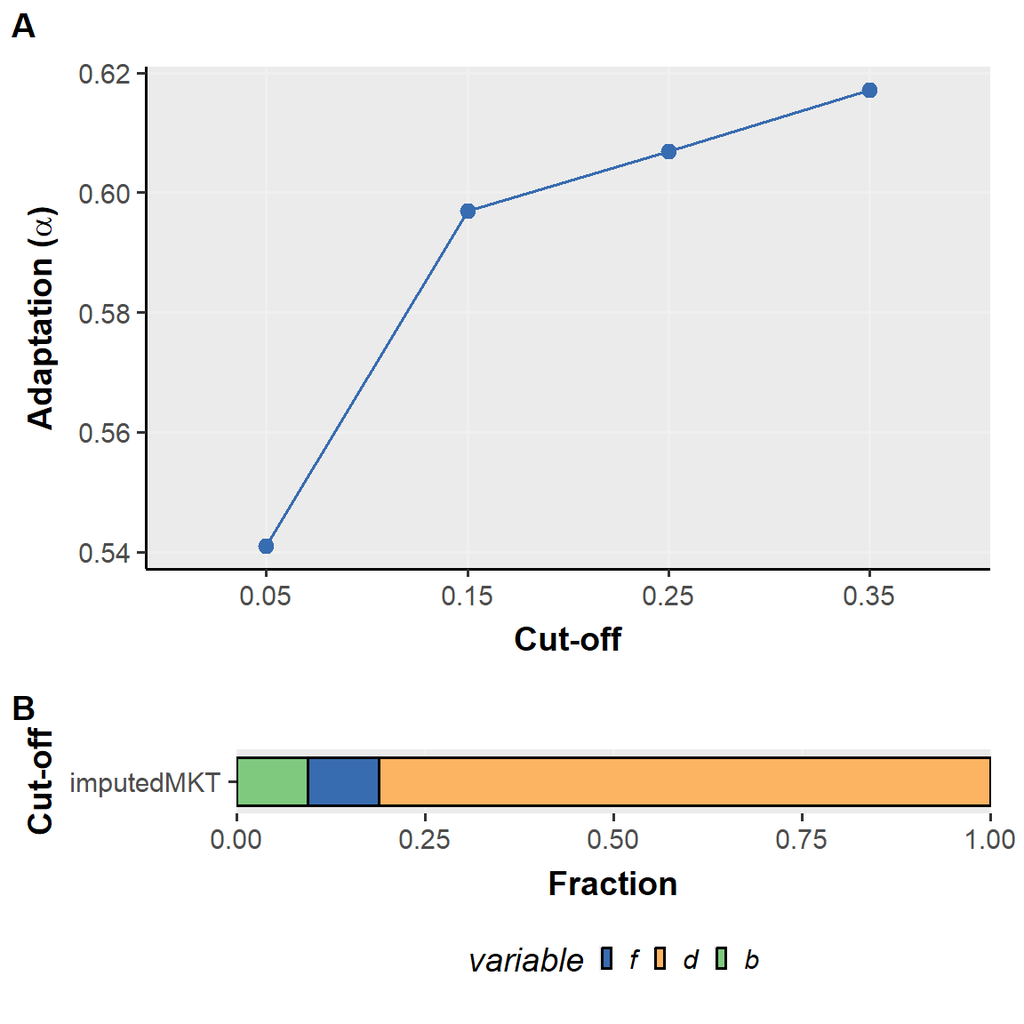

```r
imputedMKT(daf = myDafData, divergence = myDivergenceData, listCutoffs = c(0.05, 0.15,0.25,0.35), plot = TRUE)
```

### eMKT correction

This correction was originally described by Mackay et al. (2012). To take adaptive and slightly deleterious mutations mutually into account, $P_n$, the count of segregating sites in the non-synonymous class, should be separated into the number of neutral variants and the number of weakly deleterious variants, $P_n = P_{n(neutral)} + P_{n(weakly\ del.)}$. If both numbers are estimated, adaptive and weakly deleterious selection can be evaluated independently.

The estimate of the fraction of sites segregating neutrally within the DAF below the cutoff, $f_{neutral(DAF<cutoff)}$, is $P_s(DAF<cutoff) / P_s$ — the ratio of low-frequency to **total** (not just high-frequency) synonymous polymorphisms. The expected number of segregating sites in the non-synonymous class which are neutral within the DAF below the cutoff is $P_{n(neutral, DAF<cutoff)} = P_n \times f_{neutral(DAF<cutoff)}$. The expected number of neutral segregating sites in the non-synonymous class is then $P_{n(neutral)} = P_{n(neutral, DAF<cutoff)} + P_{n(DAF>cutoff)}$, and the corrected estimate of $\alpha$ is $\alpha = 1 - \frac{D_0 \cdot P_{n(neutral)}}{D_n \cdot P_s}$.

```r
eMKT(daf = myDafData, divergence = myDivergenceData, listCutoffs = c(0.05))
```

```
#> $mktTable
#>                Polymorphism Divergence
#> Neutral class         45101      52537
#> Selected class        35816      54641
#>
#> $alphaCorrected
#>             cutoff alphaCorrected pvalue
#> cutoff=0.05   0.05      0.4249071      0
#>
#> $divMetrics
#> $divMetrics$metricsByCutoff
#>             cutoff         Ka        Ks    omegaA    omegaD
#> cutoff=0.05   0.05 0.02102543 0.0847345 0.1054335 0.1426996
#>
#>
#> $fractions
#>             cutoff         d         f          b
#> cutoff=0.05   0.05 0.8105394 0.1426996 0.04676099
```

Again, it also takes the argument **listCutoffs**. The argument **plot** is set to **FALSE** by default. These parameters can be customized, like in the previous examples, where we use a list of 4 cutoffs (0.05, 0.15, 0.25, 0.35) and set the plot argument to **TRUE**.

The output in this case contains two **Graphs** which show the adaptation value ($\alpha$) and the negative selection fractions obtained using each cutoff.

```
#> $mktTable
#>                Polymorphism Divergence
#> Neutral class         45101      52537
#> Selected class        35816      54641
#>
#> $alphaCorrected
#>             cutoff alphaCorrected pvalue
#> cutoff=0.05   0.05      0.4249071      0
#> cutoff=0.15   0.15      0.3983440      0
#> cutoff=0.25   0.25      0.3718449      0
#> cutoff=0.35   0.35      0.3527647      0
#>
#> $divMetrics
#> $divMetrics$metricsByCutoff
#>             cutoff         Ka        Ks     omegaA    omegaD
#> cutoff=0.05   0.05 0.02102543 0.0847345 0.10543351 0.1426996
#> cutoff=0.15   0.15 0.02102543 0.0847345 0.09884233 0.1492908
#> cutoff=0.25   0.25 0.02102543 0.0847345 0.09226702 0.1558661
#> cutoff=0.35   0.35 0.02102543 0.0847345 0.08753258 0.1606005
#>
#>
#> $fractions
#>             cutoff         d         f          b
#> cutoff=0.05   0.05 0.8105394 0.1426996 0.04676099
#> cutoff=0.15   0.15 0.8105355 0.1492908 0.04017372
#> cutoff=0.25   0.25 0.8105368 0.1558661 0.03359710
#> cutoff=0.35   0.35 0.8105406 0.1606005 0.02885892
#>
#> $graph
```

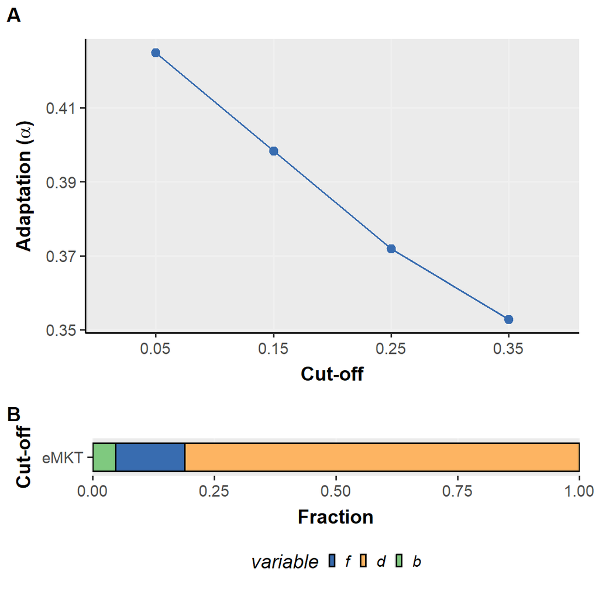

```r
eMKT(daf = myDafData, divergence = myDivergenceData, listCutoffs = c(0.05, 0.15,0.25,0.35), plot=TRUE)
```

### Asymptotic MKT

This function is adapted from the code developed in Haller and Messer (2017), stored in: http://github.com/MesserLab/asymptoticMK. The main adaptation we did is that the function presented here only fits an exponential model, removing the linear fitting performed initially in the cases where it was not possible to fit an asymptotic curve.

The **asymptoticMKT()** function uses the common DAF and divergence parameters along with two arguments which define the lower and higher limit for the asymptotic alpha fit (`xlow` and `xhigh`). These two optional parameters are set to 0 and 1 by default, although it is recommended to use a higher limit of 0.9 in order to remove possible biases due to polarization error.

The function’s output is a table with: the model type (exponential) along with the fitted function values (a, b, c), the asymptotic alpha estimate with its corresponding lower and higher confidence interval values, and the original alpha estimate (using the standard MKT methodology and the polymorphic sites within the `xlow` and `xhigh` cutoffs).

```r
asymptoticMKT(daf = myDafData, divergence = myDivergenceData, xlow = 0, xhigh = 0.9)
```

```
#>         model         a         b        c alpha_asymptotic    CI_low   CI_high
#> 1 exponential 0.6258904 -1.395108 18.96187        0.6258904 0.6045815 0.6476308
#>   alpha_original
#> 1      0.2157308
```

### aMKT (asymptotic MKT with negative selection fractions)

**aMKT()** combines the approach developed by Messer and Petrov (2013) to estimate the fraction of adaptive substitutions ($\alpha$) and an adaptation of the theoretical framework established by Mackay et al. (2012) to quantify the fraction of putatively selected sites that are under purifying selection pressures.

The **aMKT()** function takes the default input parameters (DAF and divergence), the `xlow` and `xhigh` arguments (presented in the **asymptoticMKT()** function) and it also has the optional argument **plot**, set as **FALSE** by default. However, in this example we use **plot=TRUE** to display the graphical results.

The output of the function contains: - **Asymptotic MK table**: table corresponding to the `asymptoticMKT()` function output - **Fractions of sites**: negative selection fractions ($d$: strongly deleterious, $f$: neutral and $b$: weakly deleterious) - **Graphs**: 3 plots showing (A) the distribution of allele frequencies for neutral and selected sites, (B) the asymptotic $\alpha$ estimate with `xlow`, `xhigh`, original $\alpha$ and asymptotic $\alpha$ marks, and (C) the negative selection fractions

```
#> $alphaCorrected
#>         model      a       b       c alphaAsymptotic  ciLow ciHigh
#> 1 exponential 0.6259 -1.3951 18.9619          0.6259 0.6042 0.6475
#>   alphaOriginal
#> 1        0.2157
#>
#> $fractions
#>          d          f          b
#> 1 0.810538 0.09282896 0.09663308
#>
#> $graphs
```

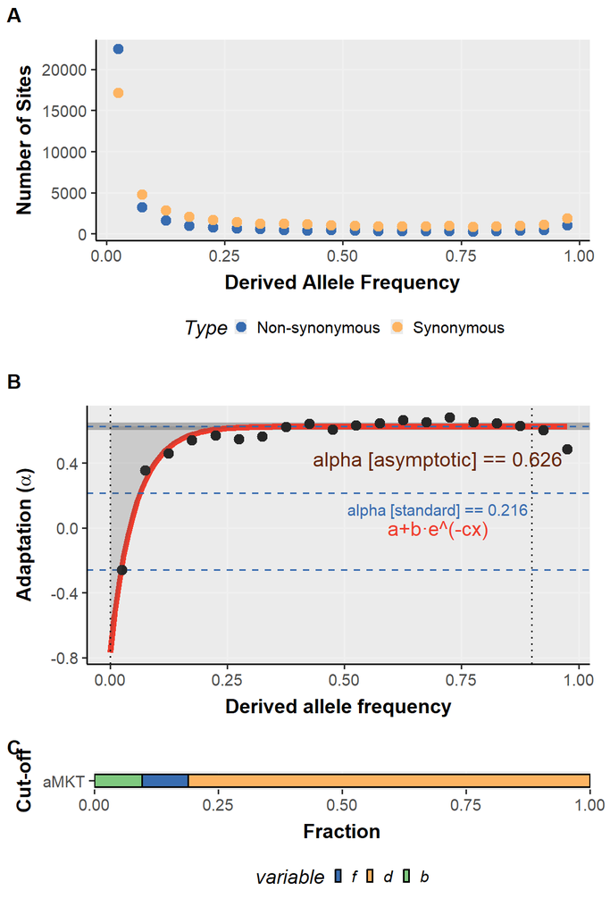

```r
aMKT(daf=myDafData, divergence=myDivergenceData, xlow=0, xhigh=0.9, plot=TRUE)
```

**Note:** `aMKT()` fits the exact same exponential model as `asymptoticMKT()` (same `xlow`/`xhigh`, same fitting procedure), so both functions return an identical asymptotic $\alpha$ estimate (up to Monte Carlo noise in the confidence interval); `aMKT()` additionally reports the negative selection fractions $d$/$f$/$b$.

## Conclusion: comparison of the different MKT estimates

The following table includes the estimates of the rate of adaptive evolution ($\alpha$) obtained using the same data and each of the MKT methods included in the iMKT package. Results for FWW, imputedMKT and eMKT corrections were produced using a 0.05 cutoff.

**Note:** imputedMKT()’s $\alpha$ is algebraically identical to FWW()’s for any dataset (both reduce to using only the polymorphism above the cutoff); they differ in the contingency table fed to the Fisher test (imputedMKT uses the total $P_0$, giving more statistical power / smaller p-values), and in that imputedMKT additionally reports the d/f/b fractions. eMKT() uses a different formula (based on the full-range synonymous ratio) and gives a genuinely different $\alpha$ estimate.

**On naming history:** the correction originally described by Mackay et al. (2012) was implemented as **DGRP()** in early versions of this package; its formula (based on the full-range synonymous ratio) is what is now exported as **eMKT()**. A separate, later improvement over FWW (Fay et al. 2001) was originally named **iMKT()**; its formula (based on the ratio above the cutoff only) is what is now exported as **imputedMKT()** (Murga-Moreno et al. 2022). At some point the name “iMKT” was reused to also refer to the asymptotic method (Messer and Petrov 2013), which is what this package now exports as **aMKT()** — this naming collision across two unrelated methods was a documentation error, not a change in either method’s underlying math.

[output not shown]

We observe that the standard MKT tends to underestimate the true rate of adaptation, probably due to the presence of weakly deleterious mutations which reduce the power of the test to detect adaptive evolution.

Besides, we observe an increase of $\alpha$ when using any of the other methods. Finally, the asymptotic method (`aMKT()`) allows to estimate the largest rate of adaptive evolution. As we are analyzing a complete chromosome arm with a large number of segregating sites (in all DAF categories), the asymptotic test is able to remove almost all weakly deleterious mutations from the analysis and thus, we obtain the $\alpha$ estimates closest to the true level of adaptation.

## References

Casillas, Sònia, and Antonio Barbadilla. 2017. “Molecular Population Genetics.” *Genetics* 205 (3): 1003–35. https://doi.org/10.1534/genetics.116.196493.

Casillas, Sònia, Roger Mulet, Pablo Villegas-Mirón, et al. 2018. “PopHuman: The Human Population Genomics Browser.” *Nucleic Acids Research* 46 (D1): D1003–10. https://doi.org/10.1093/nar/gkx943.

Fay, J. C., G. J. Wyckoff, and C. I. Wu. 2001. “Positive and Negative Selection on the Human Genome.” *Genetics* 158 (3): 1227–34. https://doi.org/10.1093/genetics/158.3.1227.

Haller, Benjamin C, and Philipp W Messer. 2017. “asymptoticMK: A Web-Based Tool for the Asymptotic McDonald–Kreitman Test.” *G3 GenesGenomesGenetics* 7 (5): 1569–75. https://doi.org/10.1534/g3.117.039693.

Hervas, Sergi, Esteve Sanz, Sònia Casillas, John E. Pool, and Antonio Barbadilla. 2017. “PopFly: The Drosophila Population Genomics Browser.” *Bioinformatics* (Oxford, England) 33 (17): 2779–80. https://doi.org/10.1093/bioinformatics/btx301.

Mackay, Trudy F. C., Stephen Richards, Eric A. Stone, et al. 2012. “The Drosophila Melanogaster Genetic Reference Panel.” *Nature* 482 (7384): 173–78. https://doi.org/10.1038/nature10811.

McDonald, J. H., and M. Kreitman. 1991. “Adaptive Protein Evolution at the Adh Locus in Drosophila.” *Nature* 351 (6328): 652–54. https://doi.org/10.1038/351652a0.

Messer, Philipp W., and Dmitri A. Petrov. 2013. “Frequent Adaptation and the McDonald-Kreitman Test.” *Proceedings of the National Academy of Sciences of the United States of America* 110 (21): 8615–20. https://doi.org/10.1073/pnas.1220835110.

Murga-Moreno, Jesús, Marta Coronado-Zamora, Sònia Casillas, and Antonio Barbadilla. 2022. “impMKT: The Imputed McDonald and Kreitman Test, a Straightforward Correction That Significantly Increases the Evidence of Positive Selection of the McDonald and Kreitman Test at the Gene Level.” *G3* (Bethesda, Md.) 12 (10): jkac206. https://doi.org/10.1093/g3journal/jkac206.